# R Programming Skill Track III

Wenxiao Zhou

6/24/2021

# The Art of Benchmarking

Premature optimization is the root of all evil. —-Popularized by *Donald Knuth*

One of the relatively easy optimization available is to use an up-to-date version of R. In general, R is very conservative, so upgrading doesn’t break existing code. However, a new version will often provide free speed boosts for key functions.

```r
# Print the R version details using version
version
```

```
##                _
## platform       x86_64-apple-darwin17.0
## arch           x86_64
## os             darwin17.0
## system         x86_64, darwin17.0
## status
## major          4
## minor          0.2
## year           2020
## month          06
## day            22
## svn rev        78730
## language       R
## version.string R version 4.0.2 (2020-06-22)
## nickname       Taking Off Again
```

```r
# Assign the variable major to the major component
major <- version$major
# Assign the variable minor to the minor component
minor <- version$minor
```

Benchmarking(基准化分析法)

1. We construct a function around the feature we wish to benchmark
2. We time the function under different scenarios, e.g. data set

```
Timing with `system.time()`
user time is the CPU time charged for the execution of user instructions.
system time is the CPU time charged for execution by the system on behalf of the calling process.
elapsed time is approximately the sum of user and system, this is the number we typically care about
```

Microbenchmark Package: Compare functions(Each function is run multiple times)

```r
library("microbenchmark")
n<-1e8
microbenchmark(1:n,
               seq(n),
              # seq_by(n),
               time=10)  # Run each function 10 times
```

```
## Unit: nanoseconds
##    expr  min     lq     mean median     uq    max neval
##     1:n  175  232.5   508.39  262.5  312.5  11403   100
##  seq(n) 3266 5080.0 15615.04 5259.5 5697.0 894882   100
##    time    2   12.0    17.37   17.0   20.0    123   100
```

Comparing read time of CSV and RDS files:

```
# How long does it take to read movies from CSV?
system.time(read.csv("movies.csv"))
# How long does it take to read movies from RDS?
system.time(readRDS("movies.rds"))
```

**Operational differences: ‘<-’ and ‘=’: using the `<-` operator inside a function call will create a new(or overwrite an existing) object**

Elapsed time

Using `system.time()` is convenient, but does have drawbacks when comparing multiple function calls. Use `microbenchmark::microbenchmark()` function to solve this problem:

<The microbenchmark() function makes it easier to compare multiple function calls at once by compiling all the relevant information in a data frame. It does this by running each function call multiple times, recording the time it took for the function to run each time, then computing summary statistics for each expression as you can see here.>

```
# Load the microbenchmark package
library(microbenchmark)
# Compare the two functions
compare <- microbenchmark(read.csv("movies.csv"),
                          readRDS("movies.rds"),
                          times = 10)

# Print compare
compare
```

**Measuring the performance of your computer is called benchmarking, and you can do that with the benchmarkme package.**

```r
# The benchmarkme package
#install.packages("benchmarkme")
library("benchmarkme")
# Run each benchmark 3 times
res<-benchmark_std(runs=3)
```

```
## # Programming benchmarks (5 tests):
```

```
##  3,500,000 Fibonacci numbers calculation (vector calc): 0.229 (sec).
```

```
##  Grand common divisors of 1,000,000 pairs (recursion): 0.673 (sec).
```

```
##  Creation of a 3,500 x 3,500 Hilbert matrix (matrix calc): 0.28 (sec).
```

```
##  Creation of a 3,000 x 3,000 Toeplitz matrix (loops): 1.08 (sec).
```

```
##  Escoufier's method on a 60 x 60 matrix (mixed): 1.37 (sec).
```

```
## # Matrix calculation benchmarks (5 tests):
```

```
##  Creation, transp., deformation of a 5,000 x 5,000 matrix: 0.504 (sec).
```

```
##  2,500 x 2,500 normal distributed random matrix^1,000: 0.152 (sec).
```

```
##  Sorting of 7,000,000 random values: 0.752 (sec).
```

```
##  2,500 x 2,500 cross-product matrix (b = a' * a): 10.4 (sec).
```

```
##  Linear regr. over a 5,000 x 500 matrix (c = a \ b'): 0.896 (sec).
```

```
## # Matrix function benchmarks (5 tests):
```

```
##  Cholesky decomposition of a 3,000 x 3,000 matrix: 5.61 (sec).
```

```
##  Determinant of a 2,500 x 2,500 random matrix: 3.22 (sec).
```

```
##  Eigenvalues of a 640 x 640 random matrix: 0.7 (sec).
```

```
##  FFT over 2,500,000 random values: 0.231 (sec).
```

```
##  Inverse of a 1,600 x 1,600 random matrix: 2.99 (sec).
```

```
## You are ranked 177 out of 749 machines.
```

```
## Press return to get next plot
```

```
## You are ranked 445 out of 747 machines.
```

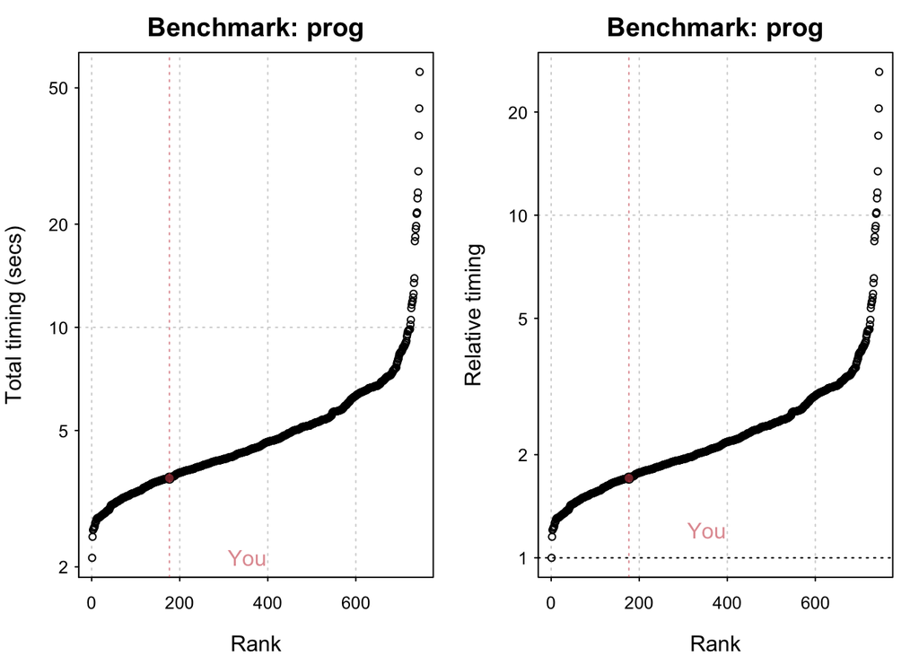

```
## Press return to get next plot
```

```
## You are ranked 458 out of 747 machines.
```

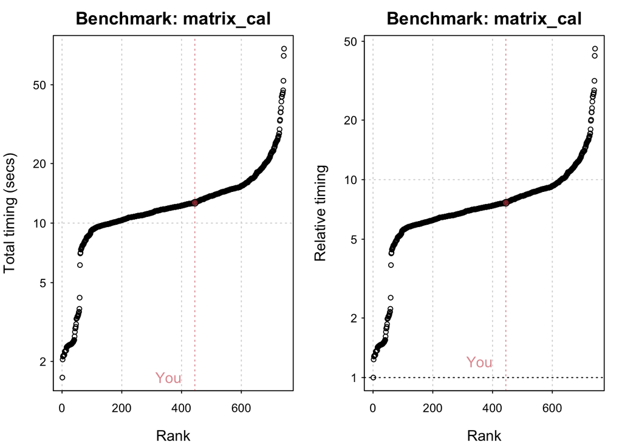

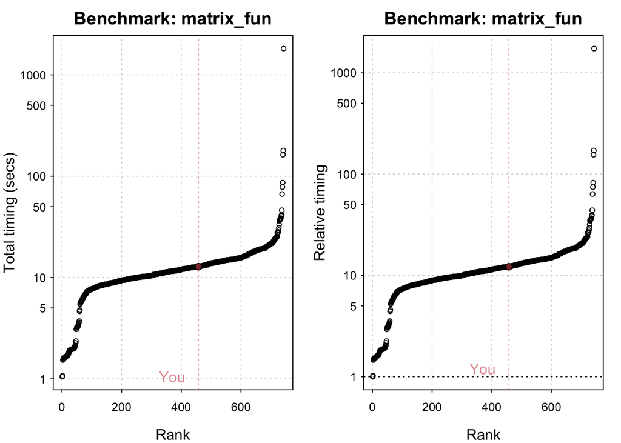

```r
plot(res)
```

```r
# Load the benchmarkme package
library(benchmarkme)

# Assign the variable ram to the amount of RAM on this machine
# Obtain the amount of RAM on this machine using get_ram()
ram <- get_ram()
ram
```

```
## 34.4 GB
```

```r
# Assign the variable cpu to the cpu specs
#Obtain the CPU specifications using get_cpu().
cpu <- get_cpu()
cpu
```

```
## $vendor_id
## [1] "GenuineIntel"
##
## $model_name
## [1] "Intel(R) Core(TM) i5-1038NG7 CPU @ 2.00GHz"
##
## $no_of_cores
## [1] 8
```

The benchmarkme package allows you to run a set of standardized benchmarks and compare your results to other users. One set of benchmarks tests is reading and writing speeds.

```r
# res=benchmark_io(runs=1,size=5)
# records the length of time it takes to read and write a 5MB file.
#plot(res)
```

# Fine Tuning: Efficient Base R

General principle: memory allocation

In R, memory allocation happens automatically. R allocates memory in RAM to store variables. Try to minimize variable assignment for speed.

```
Example: sequence of integers 1,2,...,n
(1)The obvious and best way:
x<-1:n

(2)Not so bad:
x<-vector("numeric",n)  # length n
for (i in 1:n)
   x[i]<-i

(3)Don't ever do this:
x<-NULL #length zero
for(i in 1:n)
 x<-c(x,i)
```

**The first rule of R club: never, ever grow a vector**

```r
#Compare growing a vector and
#(1) Slow code
growing <- function(n) {
    x <- NULL
    for(i in 1:n)
        x <- c(x, rnorm(1))
    x
}
# Use <- with system.time() to store the result as res_grow
n <- 30000
system.time(res_grow <-growing(n))
```

```
##    user  system elapsed
##   1.004   1.226   2.238
```

```r
#(2) Faster code
# Fast code
pre_allocate <- function(n) {
    x <- numeric(n) # Pre-allocate
    for(i in 1:n)
        x[i] <- rnorm(1)
    x
}
n <- 30000
system.time(res_allocate<-pre_allocate(n))
```

```
##    user  system elapsed
##   0.047   0.000   0.047
```

Importance of vectorizing your code:  
General rule: Calling an R function eventually leads to C or FORTRAN code.

Goal: Access the underlying C or FORTRAN code as quickly as possible. The fewer functions call the better.

*Many R functions are vectorized.*  
*Loop is slow: loop is one-million-calls to the function; vectorized is a single-call to the function.*

**The second rule of R club: use a vectorized solution wherever possible.**

```r
#Vectorized code: multiplication
x<-rnorm(10)
x2<-numeric(length(x))
for(i in 1:10)
  x2[i]<-x[i]*x[i]
#Rewrite that code using a vectorized solution. Hints:
#You should not use a for loop.
#The multiplication operator is vectorized!
x2_imp <-x*x
```

```r
#Vectorized code: calculating a log-sum
# x is a vector of probabilities
# Initial code
n <- 100
total <- 0
x <- runif(n)
for(i in 1:n)
    total <- total + log(x[i])

# Rewrite in a single line. Store the result in log_sum
log_sum <-sum(log(x))
```

Data frames and matrices:

Key data structure in R is data frame. It can be copied in other languages, e.g. Python: pandas data frame

Matrices: It’s a rectangular data structure, you can perform usual subsetting and extracting operations. But every element must be the same data type.

*Because all values in a matrix object must be the same data type, it is much faster to access the first column of a matrix than it is to access that of a data frame.*

# Diagnosing Problems: Code Profiling

# Turbo Charged Code: Parallel Programming